*⇽ home*

# Predicting the authorship of Beatles lyrics

One of my favorite things about working in a public library is the opportunity for serendipitous book recommendations—I've discovered, read, and enjoyed many of my favorite titles<sup>[1]</sup> on trips to and from the bathroom, or just when gazing into space during a moment of contemplation.

And so it was that, one afternoon this summer when I sought refuge among the temperature-controlled desks of the Mountain View Public Library, I found myself staring at a thick red spine bearing the title, ["All the Songs: The Story Behind Every Beatles Release"](https://www.abebooks.com/9781579129521/Songs-Story-Behind-Beatles-Release-1579129528/plp).

I dropped whatever it was that I had been in the middle of and grabbed the tome before some other fan could, and started flipping through—the authors, Margotin and Guesdon, had certainly done their research, providing copious details<sup>[2]</sup> about each song's genesis, development, recording, and eventual release. And crucially, they did their best to pinpoint who ultimately deserved authorship for the countless "Lennon-McCartney" (and less frequent, early-album "McCartney-Lennon") credits, citing statements given by John or Paul or others involved in various interviews and biographies. Of course, many songs were highly collaborative efforts, especially where the big 2 were concerned, with Paul having come up with some verses and John later supplying a chorus, or Paul helping to fill in gaps in John's initial lyrics. But setting aside these messier cases, Margotin and Guesdon provided a path to the cleanest dataset of Beatles lyrics labeled for writer that I had ever encountered.

Armed with this trove of data, I set out to see how well a classifier could predict a (Beatles) song's authorship based on its lyrics, and which lyrical features might be most associated with each Beatle.

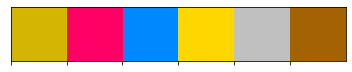

```python
import pandas as pd
import numpy as np
import re
pd.set_option('display.max_colwidth', None)
import os, pickle
from collections import Counter, defaultdict
import matplotlib.pyplot as plt
import seaborn as sns

# CUSTOM BEATLES-THEMED COLOR PALETTE
color_codes = ["#D4B504", # (Mean Mr.) Mustard
               "#FF0065", # Strawberry (Fields Forever)
               "#0089FF", # Blue (Jay Way)
               "#FFD700", # Gold(en Slumbers)
               "#C0C0C0", # (Maxwell's) Silver (Hammer)
               "#A36302",] # Penny (Lane)
color_names = ["mr. mustard", "strawberry fields", "blue jay way",
               "golden slumbers", "silver hammer", "penny lane"]
palette = sns.color_palette(color_codes)
sns.set_palette(palette)
sns.palplot(palette)

from IPython.display import Markdown, display
def printmd(string):
    display(Markdown(string))
```

# Assembling the dataset

I assembled the metadata on Beatles songs manually into a `.csv` file from [Margotin and Guesdon](https://www.abebooks.com/9781579129521/Songs-Story-Behind-Beatles-Release-1579129528/plp), which I also used to provide a verdict on each song's lyrics' authorship. In cases where the verdict is not a single Beatle, I indicate this in the `songwriter` column and provide some details in the `notes` column. I also regularized the title of each song by removing words in brackets and non-alphanumeric characters, converting hyphenated compound words into two separate tokens, and lowercasing all characters.

```python
beatles_df = pd.read_csv('song_data/beatles_era_metadata.csv', sep=',')
beatles_df['reg_song'] = beatles_df['song'].apply(lambda x: re.sub("[\[].*?[\]]", "", x.lower().replace('-',' ')))
beatles_df['reg_song'] = beatles_df['reg_song'].apply(lambda x: re.sub(r"[^A-Za-z0-9 ]+", "", x))
display(beatles_df.head())

BEATLES = {'john','paul','george','ringo'}
```

|  | song | songwriter | credits | year written | year recorded | album | notes | reg_song |
| --- | --- | --- | --- | --- | --- | --- | --- | --- |
| 0 | I Saw Her Standing There | Paul | McCartney-Lennon | 1962 | 1963 | NaN | collaborative | i saw her standing there |
| 1 | Misery | John, Paul | McCartney-Lennon | 1963 | 1963 | NaN | NaN | misery |
| 2 | Ask Me Why | John | McCartney-Lennon | 1962 | 1962 | NaN | NaN | ask me why |
| 3 | Please Please Me | John | McCartney-Lennon | 1962 | 1962 | NaN | NaN | please please me |
| 4 | Love Me Do | Paul | McCartney-Lennon | 1962 | 1962 | NaN | "Although George Martin did not like the words much, Paul claimed them as his creation." | love me do |

As Fig. 1 below indicates, a number of songs defy straightforward authorship attribution. I removed these songs from all subsequent analyses. Fig. 2 shows the number of songs each Beatle wrote over time, adhering to what we know about the asymmetry in each member's contributions.

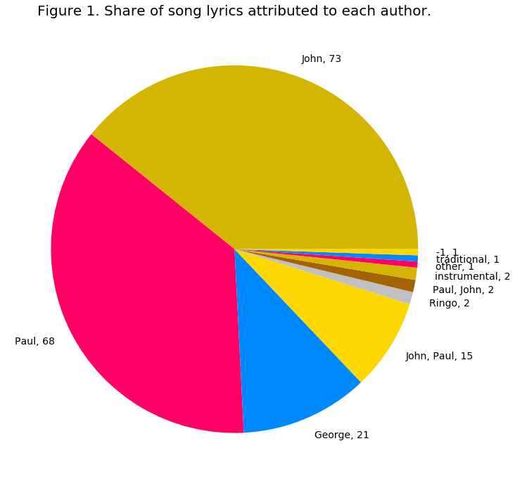

```python
writer_counts = beatles_df['songwriter'].value_counts()
beatles_df['songwriter'].apply(
    lambda x: x + ', ' + str(writer_counts[x])
    if type(x) == str
    else x).value_counts()\
.plot.pie(figsize=(12, 12), fontsize=14)
plt.ylabel("")
title = plt.title("Figure 1. Share of song lyrics attributed to each author.", fontsize=20)
```

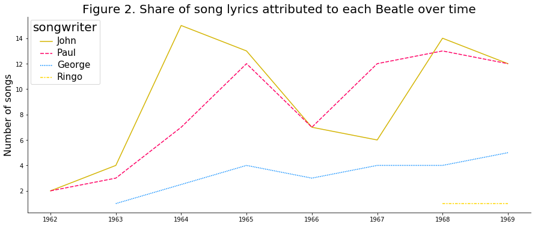

```python
beatles_df = beatles_df.loc[beatles_df['songwriter'].isin({b.capitalize() for b in BEATLES})].copy()
counts_df = beatles_df.groupby(['songwriter','year recorded']).size() \
                      .sort_values(ascending=False) \
                      .reset_index(name='count')
fig, ax = plt.subplots(figsize=(15,6))
sns.lineplot(data=counts_df.sort_values('year recorded',ascending=True),
             style='songwriter',hue='songwriter',x='year recorded',y='count',ax=ax)
sns.despine()
ax.set_ylabel("Number of songs",fontsize=16)
ax.set_xlabel("")
plt.setp(ax.get_legend().get_texts(), fontsize='15')
plt.setp(ax.get_legend().get_title(), fontsize='20')
_ = ax.set_title("Figure 2. Share of song lyrics attributed to each Beatle over time",fontsize=20)
```

## Processing lyrics

```python
save_path = 'song2lyrics.pkl'
song_title2lyrics = pickle.load(open(save_path,'rb'))
lyrics2song_title = dict(zip(song_title2lyrics.values(), song_title2lyrics.keys()))
```

One immediately noticeable aspect of the lyrics is the heavy use of repetition, both of individual words and of entire lines (both within and outside of choruses).

Since it's not particularly interesting to find that Paul uses, e.g., "raccoon" in his lyrics way more than the other Beatles, I also created deduplicated versions of the lyrics for each song by removing repeats of adjacent words and repeats of non-adjacent lines, after ignoring punctuation.

```python
song_title2dedup_lyrics = pickle.load(open('song2dedup_lyrics.pkl','rb'))
```

Here is a demo of how the deduplication script works (red tokens are the ones being removed):

```python
from utils import dedupe_lyrics

deduplicated_rocky = dedupe_lyrics(song_title2lyrics['rocky raccoon'], verbose=True)
```

```
now somewhere in the black mountain hills of dakota
there lived a young boy named rocky raccoon
and one day his woman ran off with another guy
hit young rocky in the eye rocky didnt like that
he said im gonna get that boy
so one day he walked into town
booked himself a room in the local saloon
rocky raccoon checked into his room
only to find gideons bible
rocky had come equipped with a gun
to shoot off the legs of his rival
his rival it seems had broken his dreams
by stealing the girl of his fancy
her name was magill and she called herself lil
but everyone knew her as nancy
now she and her man who called himself dan
were in the next room at the hoedown
rocky burst in and grinning a grin
he said danny boy this is a showdown
but daniel was hot he drew first and shot
and rocky collapsed in the corner ah
dda dda dda da da da
dda dda dda da da da
dda dda dda da dda dda dda dda
do do do do do do
ddo ddo ddo do do do
ddo ddo ddo do do do
ddo ddo ddo do do ddo ddo ddo ddo
do do do do do do
now the doctor came in stinking of gin
and proceeded to lie on the table
he said rocky you met your match
and rocky said doc its only a scratch
and ill be better ill be better doc as soon as i am able
and now rocky raccoon he fell back in his room
only to find gideons bible
gideon checked out and he left it no doubt
to help with good rockys revival ah
oh yeah yeah
ddo ddo ddo do do do
ddo ddo ddo do do do
ddo ddo ddo do do ddo ddo ddo ddo
do do do do do do
ddo ddo ddo do do do come on rocky boy
ddo ddo ddo do do do come on rocky boy
ddo ddo ddo do do ddo ddo ddo ddo
the story of rocky there
```

Next, I used [spaCy](https://spacy.io/) to preprocess all the *deduplicated* lyrics by applying tokenization, lemmatization, POS-tagging, and dependency parsing. Let's load the serialized results into a dictionary keyed by song title, `song_title2doc`:

```python
import spacy
from spacy.tokens import DocBin

nlp = spacy.load("en_core_web_sm")
bytes_data = pickle.load(open('pickled_spacy_docs/bytes_data.pkl','rb'))
doc_bin = DocBin().from_bytes(bytes_data)
docs = list(doc_bin.get_docs(nlp.vocab))
song_title2doc = dict(zip(song_title2dedup_lyrics.keys(), docs))
```

And inspect some sample preprocessed output:

```python
for tok in song_title2doc['here comes the sun']:
    print(tok.text, tok.lemma_, tok.pos_, tok.head.text, tok.dep_)
```

```
here here ADV comes advmod
comes come VERB comes ROOT
the the DET doo det
sun sun PROPN doo compound
doo doo PROPN doo compound
- - PUNCT doo punct
doo doo NOUN doo compound
- - PUNCT doo punct
doo doo NOUN doo compound
- - PUNCT doo punct
doo doo NOUN comes nsubj
here here ADV comes advmod
comes come VERB comes conj
the the DET sun det
sun sun NOUN comes nsubj


 SPACE sun dep
and and CCONJ comes cc
i I PRON say nsubj
say say VERB comes conj
its its PRON little poss
all all PRON right advmod
right right ADJ little amod


 SPACE right dep
little little ADJ darling amod
darling darle VERB been nsubj
its its PRON been nsubj
been be AUX say ccomp
a a DET darling det
long long ADJ winter amod
cold cold ADJ winter amod
lonely lonely ADJ winter amod
winter winter NOUN little compound


 SPACE winter dep
little little ADJ darling amod
```

[output cut: 56 more lines]

```
darling darling NOUN melting dobj
it it PRON seems nsubj
seems seem VERB feel ccomp
like like ADP seems prep
years year NOUN like pobj
since since SCONJ been mark
its its PRON been nsubj
been be AUX seems advcl
clear clear ADJ been acomp


 SPACE clear dep
its its PRON right poss
all all ADV right advmod
right right NOUN right ROOT
```

After deduplication, there is a total of 23.4K tokens and 1.8K unique lemma types in the entire dataset of 164 songs.

```python
total_num_tokens = len([tok for song_title in song_title2doc
                        if song_title in set(beatles_df['reg_song'].values)
                        for tok in song_title2doc[song_title]])
total_num_lemmas = len(set([tok.lemma_  for song_title in song_title2doc
                            if song_title in set(beatles_df['reg_song'].values)
                            for tok in song_title2doc[song_title]]))
print(total_num_tokens, total_num_lemmas,
      len(set(song_title2doc.keys()).intersection(set(beatles_df['reg_song'].values))))
```

```
23379 1819 164
```

Now, we can move onto training some classifiers!

# Training classifiers

I experimented with using both a deep learning and non-deep logistic regression model to classify lyrics for author, namely:

- a BERT fine-tuned on the labeled lyrics data;
- a multi-class logistic regression classifier using ngram, tf-idf, pronoun, negation, valence, arousal, dominance, TTR, and length features

I also implemented the following baseline models for comparison:

- majority class;
- random guess w/ informative prior scaled by size of each class.

Finally, since Ringo is only represented a grand total of 2 times in the dataset, I limit the classification task to the other 3. Sorry, Ringo!!

```python
# Create train, eval data splits

## Convert names into integers for classification data;
beatle2int_label = {b: i for i, b in enumerate(BEATLES)}
print('Conversion scheme:', beatle2int_label)
int_label2beatle = {i: b for i, b in enumerate(BEATLES)}

song_title2author = dict(zip(beatles_df['reg_song'].values,
                             beatles_df['songwriter'].apply(
                                 lambda x: x.lower() if type(x) == str else x).values))
songs_without_lyrics = [song for song in beatles_df['reg_song'].values if song not in song_title2lyrics]

## Exclude songs with multiple writers;
combined_texts_with_labels = [(song_title2lyrics[song], song_title2author[song])
                              for song in beatles_df['reg_song'].values
                              if song in song_title2lyrics
                              and song_title2author[song] in {'john','paul','george'}]
print(f"Assembled {len(combined_texts_with_labels)} (lyrics, label) datapoints to use for train/eval data.\n")
print("Excluding the following songs without lyrics:", songs_without_lyrics)

RANDOM_SEED = 1969
np.random.seed(RANDOM_SEED)
train_n = int(len(combined_texts_with_labels)*0.8)
eval_n = len(combined_texts_with_labels) - train_n
print(f"Creating train/eval splits of size {train_n}, {eval_n}, respectively.")
train_ixs = set(np.random.choice(a=list(range(len(combined_texts_with_labels))), size=train_n, replace=False))
eval_ixs = set(range(len(combined_texts_with_labels))).difference(train_ixs)
assert train_ixs.intersection(eval_ixs) == set()

train_texts_with_labels = [combined_texts_with_labels[ix] for ix in train_ixs]
eval_texts_with_labels = [combined_texts_with_labels[ix] for ix in eval_ixs]
print(f"\nDistribution of train labels:", Counter([item[1] for item in train_texts_with_labels]))
print(f"Distribution of eval labels:", Counter([item[1] for item in eval_texts_with_labels]))

train_texts = [item[0] for item in train_texts_with_labels]
train_labels = [item[1] for item in train_texts_with_labels]

eval_texts = [item[0] for item in eval_texts_with_labels]
eval_labels = [item[1] for item in eval_texts_with_labels]
```

```
Conversion scheme: {'paul': 0, 'ringo': 1, 'george': 2, 'john': 3}
Assembled 162 (lyrics, label) datapoints to use for train/eval data.

Excluding the following songs without lyrics: []
Creating train/eval splits of size 129, 33, respectively.

Distribution of train labels: Counter({'john': 56, 'paul': 55, 'george': 18})
Distribution of eval labels: Counter({'john': 17, 'paul': 13, 'george': 3})
```

Next, I extracted the following features for each song's lyrics:

- `ngram` (ranging from unigrams to 4-grams, excluding ngrams occurring in fewer than 5 songs)
- `tf-idf`
- `first.sg` (count of "I", "me", "my", and "mine")
- `first.pl` (count of "we", "us", "our", and "ours")
- `second` (count of "you", "your", and "yours")
- `third.sg.f` (count of "she", "her", and "hers")
- `third.sg.m` (count of "he", "him", and "his")
- `third.sg.n` (count of "it", "its")
- `third.pl` (count of "they", "them", "their", and "theirs")
- `neg` (count of {'no','not','n't','nothing','never','noone','nowhere'}
- `valence` (sum of valence norms for all words with ratings in the [Mohammad et al. (2018) lexicon](https://saifmohammad.com/WebPages/nrc-vad.html)
- `arousal` (sum of arousal norms for all words with ratings in the [Mohammad et al. (2018) lexicon](https://saifmohammad.com/WebPages/nrc-vad.html)
- `dominance` (sum of dominance norms for all words with ratings in the [Mohammad et al. (2018) lexicon](https://saifmohammad.com/WebPages/nrc-vad.html)
- `ttr` (type to token ratio over all words in the song)
- `total_num_words` (the total number of tokens in the song)
- `total_num_lemmas` (the total number of unique types in the song)
- `total_num_lines` (the total number of lines in the song)
- `mean_line_len` (the average number of tokens per line)
- `mean_word_len` (the average number of characters per token)

Train and evaluate the performance of the multi-class logistic regression model:

```python
# Logistic regression w/ different combinations of features

from sklearn.metrics import accuracy_score, precision_recall_fscore_support, classification_report
from sklearn.feature_extraction.text import CountVectorizer, TfidfVectorizer
from sklearn.linear_model import LogisticRegression
from sklearn.pipeline import FeatureUnion
import warnings
warnings.filterwarnings("ignore")

from utils import *

ngram_vectorizer = CountVectorizer(analyzer='word', ngram_range=(1,4), min_df=5)
tfidf_vectorizer = TfidfVectorizer(min_df=5)
combined_features = FeatureUnion([("ngram", ngram_vectorizer),
                                  ("tfidf", tfidf_vectorizer),
                                  ("ttr", TTRExtractor()),
                                  ("first.sg", FirstSgPronounExtractor()),
                                  ("first.pl", FirstPlPronounExtractor()),
                                  ("second", SecondPronounExtractor()),
                                  ("she", ShePronounExtractor()),
                                  ("he", HePronounExtractor()),
                                  ("it", ItPronounExtractor()),
                                  ("they", TheyPronounExtractor()),
                                  ("valence", ValenceExtractor()),
                                  ("arousal", ArousalExtractor()),
                                  ("dominance", DominanceExtractor()),
                                  ("neg", NegationExtractor()),
                                  ("total_lines", TotalLinesExtractor()),
                                  ("total_words", TotalWordsExtractor()),
                                  ("total_lemmas", TotalLemmasExtractor()),
                                  ("mean_words", MeanWordsPerLineExtractor()),
                                  ("mean_chars", MeanCharsPerWordExtractor()),
                                 ])

# Use combined features to transform dataset:
print(f'Extracting features...')
X_train = combined_features.fit_transform(train_texts)
X_test = combined_features.transform(eval_texts)
print(f'\tObtained the following dimensions of train, test data:',X_train.shape, X_test.shape)

lr_model = LogisticRegression(max_iter=2000,).fit(X_train, train_labels)
lr_predictions = lr_model.predict(X_test)

print(classification_report(eval_labels, lr_predictions))
```

```
Extracting features...
	Obtained the following dimensions of train, test data: (129, 946) (33, 946)
              precision    recall  f1-score   support

      george       0.00      0.00      0.00         3
        john       0.69      0.53      0.60        17
        paul       0.44      0.62      0.52        13

    accuracy                           0.52        33
   macro avg       0.38      0.38      0.37        33
weighted avg       0.53      0.52      0.51        33
```

Ablation analysis to see which features are important:

```python
all_feats = [item[0] for item in combined_features.transformer_list]
best_lr_model = lr_model
best_acc = accuracy_score(eval_labels, lr_predictions)
for ablated_feat in all_feats:
    ablated_features = FeatureUnion([feat for feat in combined_features.transformer_list
                                     if feat[0] != ablated_feat])

    print(f'Extracting ablated features without {ablated_feat}...')
    X_train = ablated_features.fit_transform(train_texts)
    X_test = ablated_features.transform(eval_texts)
    print(f'\tObtained the following dimensions of train, test data:',X_train.shape, X_test.shape)

    model_ = LogisticRegression(max_iter=1000).fit(X_train, train_labels)
    predictions = model_.predict(X_test)

    print(classification_report(eval_labels, predictions))
    curr_acc = accuracy_score(eval_labels, predictions)
    if curr_acc > best_acc:
        best_lr_model = model_
        best_feat_set = ablated_features.transformer_list
        best_acc = curr_acc
```

```
Extracting ablated features without ngram...
	Obtained the following dimensions of train, test data: (129, 359) (33, 359)
              precision    recall  f1-score   support

      george       0.00      0.00      0.00         3
        john       0.62      0.47      0.53        17
        paul       0.47      0.54      0.50        13

    accuracy                           0.45        33
   macro avg       0.36      0.34      0.34        33
weighted avg       0.50      0.45      0.47        33

Extracting ablated features without tfidf...
	Obtained the following dimensions of train, test data: (129, 604) (33, 604)
              precision    recall  f1-score   support

      george       0.00      0.00      0.00         3
        john       0.69      0.53      0.60        17
        paul       0.44      0.62      0.52        13

    accuracy                           0.52        33
   macro avg       0.38      0.38      0.37        33
weighted avg       0.53      0.52      0.51        33

Extracting ablated features without ttr...
	Obtained the following dimensions of train, test data: (129, 945) (33, 945)
              precision    recall  f1-score   support

      george       0.00      0.00      0.00         3
        john       0.69      0.53      0.60        17
        paul       0.44      0.62      0.52        13

    accuracy                           0.52        33
   macro avg       0.38      0.38      0.37        33
weighted avg       0.53      0.52      0.51        33

Extracting ablated features without first.sg...
	Obtained the following dimensions of train, test data: (129, 945) (33, 945)
              precision    recall  f1-score   support

```

[output cut: 172 more lines]

```
    accuracy                           0.52        33
   macro avg       0.40      0.38      0.38        33
weighted avg       0.56      0.52      0.52        33

Extracting ablated features without mean_chars...
	Obtained the following dimensions of train, test data: (129, 945) (33, 945)
              precision    recall  f1-score   support

      george       0.00      0.00      0.00         3
        john       0.69      0.53      0.60        17
        paul       0.44      0.62      0.52        13

    accuracy                           0.52        33
   macro avg       0.38      0.38      0.37        33
weighted avg       0.53      0.52      0.51        33
```

[output not shown]

The best performing model/feature set includes all features except the `second` person pronoun feature, and attains an accuracy of 54.5%.

```python
best_acc, [feat_name for feat_name, feat in best_feat_set]
```

```
(0.5454545454545454,
 ['ngram',
  'tfidf',
  'ttr',
  'first.sg',
  'first.pl',
  'she',
  'he',
  'it',
  'they',
  'valence',
  'arousal',
  'dominance',
  'neg',
  'total_lines',
  'total_words',
  'total_lemmas',
  'mean_words',
  'mean_chars'])
```

Let's also examine the feature weights of the best performing model to see which features are most associated with each class (i.e., Beatle).

It looks like **John's** lyrics tend to have **longer lines** in the average number of tokens, and contain words with **high dominance and arousal**. On the other hand, **Paul's** lyrics tend to have **high valence, or positive sentiment**, words, and he also uses a lot of **"he," "she," and "we" pronouns**. Finally, **George** uses a greater **diversity of token types**, as indicated by the high feature importance of `total.lemmas`, and he also tends to use a lot of **"they" pronouns and negation**.

```python
ngram_feats = [item[0] for item in sorted(ngram_vectorizer.vocabulary_.items(),
                                          key=lambda x: x[1], reverse=False)]
tfidf_feats = [item[0] for item in sorted(tfidf_vectorizer.vocabulary_.items(),
                                          key=lambda x: x[1], reverse=False)]
feat_name2weight_per_beatle = {}
for label in [0, 1, 2]:
    feat_name2weight_per_beatle[{0:'george',1:'john',2:'paul'}[label]] = dict(zip(ngram_feats + tfidf_feats + \
                            [feat_name.upper() for feat_name, feat in best_feat_set][2:],
                             best_lr_model.coef_[label]))

top_feats_per_beatle = {}
for beatle in feat_name2weight_per_beatle:
    top_feats = sorted(feat_name2weight_per_beatle[beatle].items(), key=lambda x: x[1], reverse=True)[:20]
    top_feats_per_beatle[beatle] = [(item[0], round(item[1], 3)) for item in top_feats]
pd.DataFrame(top_feats_per_beatle)
```

|  | george | john | paul |
| --- | --- | --- | --- |
| 0 | (TOTAL_LEMMAS, 0.198) | (MEAN_WORDS, 0.206) | (VALENCE, 0.234) |
| 1 | (THEY, 0.192) | (let me, 0.19) | (what you, 0.177) |
| 2 | (NEG, 0.149) | (ll be, 0.161) | (HE, 0.164) |
| 3 | (don know, 0.137) | (me so, 0.156) | (SHE, 0.151) |
| 4 | (oh oh, 0.089) | (DOMINANCE, 0.15) | (you you, 0.144) |
| 5 | (want to, 0.08) | (you know, 0.142) | (on the, 0.143) |
| 6 | (you re, 0.067) | (the world, 0.136) | (FIRST.PL, 0.133) |
| 7 | (the sun, 0.067) | (the sky, 0.116) | (and in, 0.122) |
| 8 | (too much, 0.057) | (AROUSAL, 0.116) | (you won, 0.12) |
| 9 | (IT, 0.054) | (that you, 0.108) | (to the, 0.111) |
| 10 | (it all, 0.053) | (in your, 0.092) | (love you, 0.099) |
| 11 | (don want, 0.052) | (it so, 0.089) | (to get, 0.08) |
| 12 | (if you, 0.05) | (do you, 0.089) | (to make, 0.072) |
| 13 | (with you, 0.049) | (you ve, 0.089) | (oh oh, 0.071) |
| 14 | (ve got, 0.049) | (well you, 0.078) | (to say, 0.067) |
| 15 | (yeah yeah yeah, 0.048) | (me down, 0.077) | (back to, 0.066) |
| 16 | (be there, 0.047) | (in love with you, 0.077) | (you say, 0.064) |
| 17 | (tell you, 0.046) | (love with you, 0.077) | (me the, 0.063) |
| 18 | (be the, 0.046) | (yes you, 0.073) | (in my, 0.062) |
| 19 | (don want to, 0.044) | (can you, 0.072) | (make it, 0.061) |

Can we beat this performance with a fine-tuned BERT? It seems like the feature-based LR model actually performs better on this dataset!

```python
import torch
from transformers import DistilBertTokenizerFast, DistilBertForSequenceClassification
from transformers import Trainer, TrainingArguments
from sklearn.metrics import accuracy_score, classification_report

model_name = 'distilbert-base-cased'
device_name = 'cuda'
max_length = 512
cached_model_directory_name = 'distilbert-beatles-clf'

# Encode data
tokenizer = DistilBertTokenizerFast.from_pretrained(model_name)
unique_labels = set(label for label in train_labels)
label2id = {label: id for id, label in enumerate(unique_labels)}
id2label = {id: label for label, id in label2id.items()}

train_encodings = tokenizer(train_texts, truncation=True, padding=True, max_length=max_length)
test_encodings  = tokenizer(eval_texts, truncation=True, padding=True, max_length=max_length)

train_labels_encoded = [label2id[y] for y in train_labels]
test_labels_encoded  = [label2id[y] for y in eval_labels]

class MyDataset(torch.utils.data.Dataset):
    def __init__(self, encodings, labels):
        self.encodings = encodings
        self.labels = labels

    def __getitem__(self, idx):
        item = {key: torch.tensor(val[idx]) for key, val in self.encodings.items()}
        item['labels'] = torch.tensor(self.labels[idx])
        return item

    def __len__(self):
        return len(self.labels)

train_dataset = MyDataset(train_encodings, train_labels_encoded)
test_dataset = MyDataset(test_encodings, test_labels_encoded)

bert_model = DistilBertForSequenceClassification.from_pretrained(model_name, num_labels=len(id2label))\
                                                .to(device_name)
training_args = TrainingArguments(
    num_train_epochs=3,              # total number of training epochs
    per_device_train_batch_size=16,  # batch size per device during training
    per_device_eval_batch_size=20,   # batch size for evaluation
    learning_rate=5e-5,              # initial learning rate for Adam optimizer
    warmup_steps=100,                # number of warmup steps for learning rate scheduler (set lower because of small dataset size)
    weight_decay=0.01,               # strength of weight decay
    output_dir='./results',          # output directory
    logging_dir='./logs',            # directory for storing logs
    logging_steps=100,               # number of steps to output logging (set lower because of small dataset size)
    evaluation_strategy='steps',     # evaluate during fine-tuning so that we can see progress
)

def compute_metrics(pred):
    labels = pred.label_ids
    preds = pred.predictions.argmax(-1)
    acc = accuracy_score(labels, preds)
    return {
      'accuracy': acc,
    }

trainer = Trainer(
    model=bert_model,                         # the instantiated 🤗 Transformers model to be trained
    args=training_args,                  # training arguments, defined above
    train_dataset=train_dataset,         # training dataset
    eval_dataset=test_dataset,           # evaluation dataset (usually a validation set; here we just send our test set)
    compute_metrics=compute_metrics      # our custom evaluation function
)

trainer.train()

print(f"Saving model to: {cached_model_directory_name}")
trainer.save_model(cached_model_directory_name)

trainer.evaluate()
predicted_results = trainer.predict(test_dataset)

bert_predicted_labels = predicted_results.predictions.argmax(-1)      # Get the highest probability prediction
bert_predicted_labels = bert_predicted_labels.flatten().tolist()      # Flatten the predictions into a 1D list
bert_predicted_labels = [id2label[l] for l in bert_predicted_labels]  # Convert from integers back to strings for readability

print(classification_report(eval_labels, bert_predicted_labels))
```

[output not shown]

[27/27 00:07, Epoch 3/3]

| Step | Training Loss | Validation Loss |
| --- | --- | --- |

```
Training completed. Do not forget to share your model on huggingface.co/models =)


Saving model checkpoint to distilbert-beatles-clf
Configuration saved in distilbert-beatles-clf/config.json
```

```
Saving model to: distilbert-beatles-clf
```

```
Model weights saved in distilbert-beatles-clf/pytorch_model.bin
***** Running Evaluation *****
  Num examples = 33
  Batch size = 20
```

[2/2 00:00]

```
***** Running Prediction *****
  Num examples = 33
  Batch size = 20
```

```
              precision    recall  f1-score   support

      george       0.00      0.00      0.00         3
        john       0.00      0.00      0.00        17
        paul       0.39      1.00      0.57        13

    accuracy                           0.39        33
   macro avg       0.13      0.33      0.19        33
weighted avg       0.16      0.39      0.22        33
```

But at the same time, the best-performing LR classifier (w/o the `second` person feature) is comparable to our baselines:

```python
# majority class baseline
MAJ_CLASS = Counter(train_labels).most_common()[0][0]
maj_class_preds = [MAJ_CLASS] * len(eval_labels)
print(classification_report(eval_labels, maj_class_preds))
```

```
              precision    recall  f1-score   support

      george       0.00      0.00      0.00         3
        john       0.52      1.00      0.68        17
        paul       0.00      0.00      0.00        13

    accuracy                           0.52        33
   macro avg       0.17      0.33      0.23        33
weighted avg       0.27      0.52      0.35        33
```

```python
# random guess with informative prior
prior_probs = [(item[0],item[1]/len(train_labels)) for item in Counter(train_labels).most_common()]
print('Prior label probabilities:',prior_probs)
random_with_prior_preds = []
for i in range(len(eval_labels)):
    guess = np.random.choice([item[0] for item in prior_probs], size=1, replace=False,
                             p=[item[1] for item in prior_probs])[0]
    #print(guess)
    random_with_prior_preds.append(guess)
print(len(random_with_prior_preds))
print('Distribution of guesses with informed prior:',
      [(item[0],item[1]/len(eval_labels)) for item in Counter(random_with_prior_preds).most_common()])
print('\n')
print(classification_report(eval_labels, random_with_prior_preds))
```

```
Prior label probabilities: [('john', 0.43410852713178294), ('paul', 0.4263565891472868), ('george', 0.13953488372093023)]
33
Distribution of guesses with informed prior: [('john', 0.5454545454545454), ('paul', 0.36363636363636365), ('george', 0.09090909090909091)]


              precision    recall  f1-score   support

      george       0.33      0.33      0.33         3
        john       0.61      0.65      0.63        17
        paul       0.50      0.46      0.48        13

    accuracy                           0.55        33
   macro avg       0.48      0.48      0.48        33
weighted avg       0.54      0.55      0.54        33
```

Let's examine the misclassifications to get a sense of the classifiers' shortcomings:

```
Extracting best performing combination of features: ['ngram', 'tfidf', 'ttr', 'first.sg', 'first.pl', 'she', 'he', 'it', 'they', 'valence', 'arousal', 'dominance', 'neg', 'total_lines', 'total_words', 'total_lemmas', 'mean_words', 'mean_chars']...
```

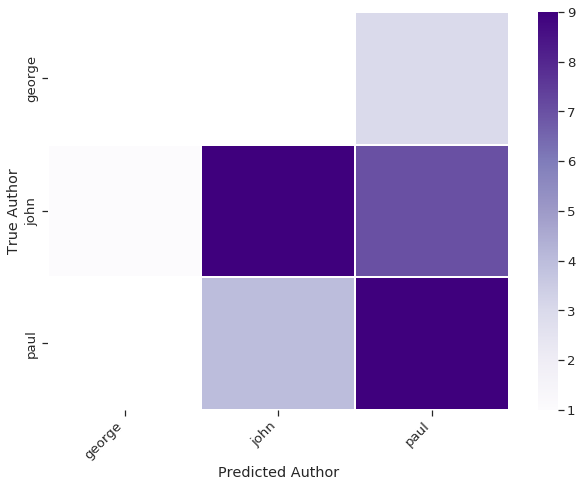

```python
# LR confusion matrix shows a lot of confusion b/w Paul and John, and George is not getting predicted at all

print(f'Extracting best performing combination of features: {[feat[0] for feat in best_feat_set]}...')
X_test = FeatureUnion(best_feat_set).transform(eval_texts)
best_lr_predictions = best_lr_model.predict(X_test)

classifications_dict = defaultdict(int)
for _true_label, _predicted_label in zip(eval_labels, best_lr_predictions):
    classifications_dict[(_true_label, _predicted_label)] += 1

dicts_to_plot = []
for (_true_author, _predicted_author), _count in classifications_dict.items():
    dicts_to_plot.append({'True Author': _true_author,
                        'Predicted Author': _predicted_author,
                        'Number of Classifications': _count})

df_to_plot = pd.DataFrame(dicts_to_plot)
df_wide = df_to_plot.pivot_table(index='True Author',
                                 columns='Predicted Author',
                                 values='Number of Classifications')

plt.figure(figsize=(9,7))
sns.set(style='ticks', font_scale=1.2)
sns.heatmap(df_wide, linewidths=1, cmap='Purples')
plt.xticks(rotation=45, ha='right')
plt.tight_layout()
plt.show()
```

- Paul's songs with more negative lyrics about experiencing difficulties get classified as John's
  - "We Can Work It Out", though overall positive, contains references to conflict— **"life is very short and theres no time / for fussing and fighting my friend", "there's a chance that we might fall apart before too long", "do I have to keep on talking till I can't go on"**
  - "Yesterday" is similar— **"yesterday all my troubles seemed so far away", "there's a shadow hanging over me", "I said something wrong", "now I need a place to hide away"**
- John's songs that are a bit more "quaint" get misclassified as Paul's
  - "Good Night" is a rare lullaby written by John;
  - "Run For Your Life" has the refrain "little girl";
  - "Cry Baby Cry" revoles around nouns such as "mother", "queen", "king", "playroom", "holiday"

```python
comp_df = pd.DataFrame({
    'song':[lyrics2song_title[x] for x in eval_texts],
    'true':eval_labels,
    'predicted':best_lr_predictions
})
comp_df.loc[comp_df['true']!=comp_df['predicted']].sort_values(['true','predicted'])
```

|  | song | true | predicted |
| --- | --- | --- | --- |
| 1 | its all too much | george | paul |
| 10 | i me mine | george | paul |
| 30 | long long long | george | paul |
| 5 | sun king | john | george |
| 2 | come together | john | paul |
| 4 | not a second time | john | paul |
| 14 | help | john | paul |
| 18 | norwegian wood this bird has flown | john | paul |
| 20 | run for your life | john | paul |
| 31 | cry baby cry | john | paul |
| 32 | good night | john | paul |
| 9 | carry that weight | paul | john |
| 17 | yesterday | paul | john |
| 21 | we can work it out | paul | john |
| 22 | corridor music | paul | john |

The BERT confusion matrix shows some serious majority class behavior, guessing only Paul!

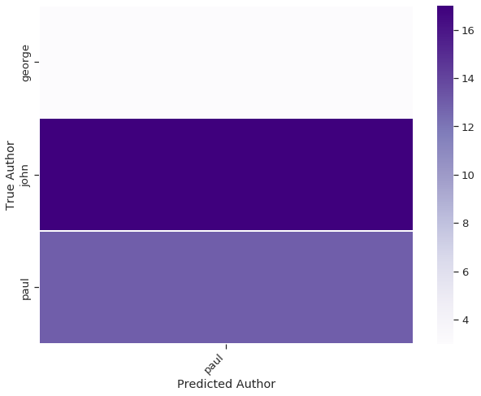

```python
classifications_dict = defaultdict(int)
for _true_label, _predicted_label in zip(eval_labels, bert_predicted_labels):
    classifications_dict[(_true_label, _predicted_label)] += 1

dicts_to_plot = []
for (_true_author, _predicted_author), _count in classifications_dict.items():
    dicts_to_plot.append({'True Author': _true_author,
                        'Predicted Author': _predicted_author,
                        'Number of Classifications': _count})

df_to_plot = pd.DataFrame(dicts_to_plot)
df_wide = df_to_plot.pivot_table(index='True Author',
                                 columns='Predicted Author',
                                 values='Number of Classifications')

plt.figure(figsize=(9,7))
sns.set(style='ticks', font_scale=1.2)
sns.heatmap(df_wide, linewidths=1, cmap='Purples')
plt.xticks(rotation=45, ha='right')
plt.tight_layout()
plt.show()
```